# Reading Dataset and Feature Elimination

## Early stopping

As mentioned earlier, loss function for validation set stops decreasing and start increasing after certain epoch. We can try to catch this moment and stop training NN to avoid overfitting

```python
early_stop_cb = ks.callbacks.EarlyStopping(
    monitor="val_loss",
    min_delta=0,
    patience=20,
    verbose=0,
    mode="min",
    baseline=None,
    restore_best_weights=True)

callbacks = [early_stop_cb,]
```

```python
model,history = buildNeuralNetwork(n_layers, n_nodes, activation, loss_f, optimizer, mult, batch,
                   epochs, X_train_np, y_train_np,
                   n_inputs, do_rate, callbacks, verbose)
```

```
Change LR from 0.0010000000474974513 to <tf.Variable 'learning_rate:0' shape=() dtype=float32, numpy=0.001>
```

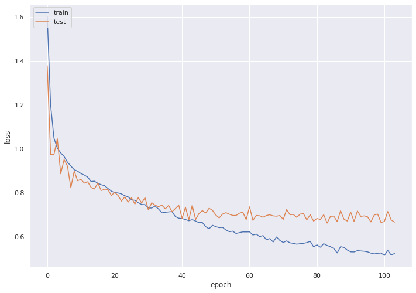

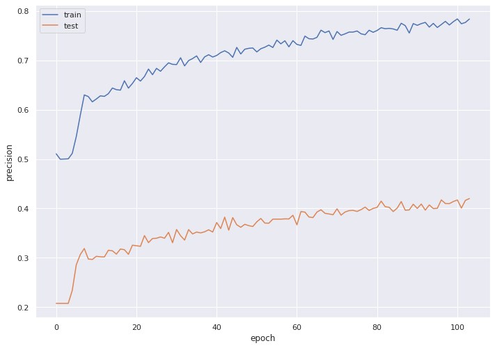

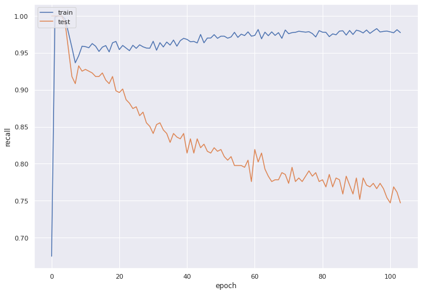

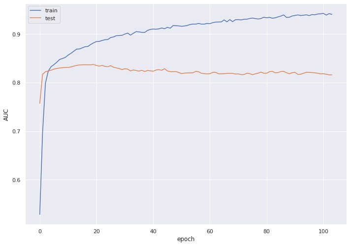

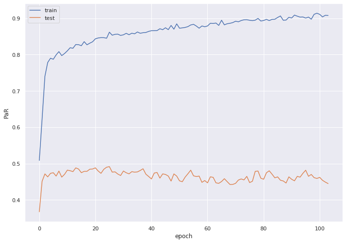

```python
plot_history(history, ['loss', 'precision', 'recall', 'AUC', 'PaR'])
```

```python
r, p, f1, cm, custom = get_model_metrics(model, X_train_np, y_train_np, 0.5, 1)
```

```
Recall: 1.0, Precision: 0.81, f1:0.9, custom metric:0.92:
```

```python
r, p, f1, cm, custom = get_model_metrics(model, X_test_np, y_test_np, 0.5, 1)
```

```
Recall: 0.79, Precision: 0.43, f1:0.56, custom metric:0.77:
```

```python
result = {'name': 'Early stop', 'recall' : r, 'precision': p, 'f1_score': f1, 'custom_metric': custom}
model_results.append(result)
```

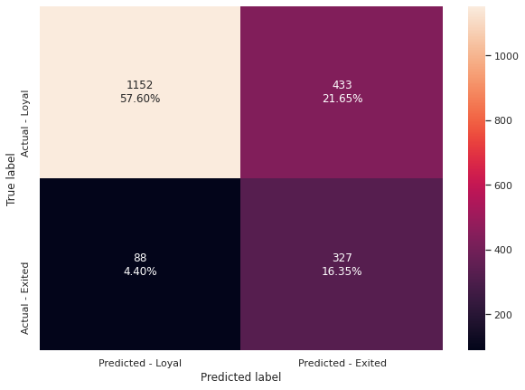

```python
make_confusion_matrix(cm)
```

Early stop improved recall, but precision degraded. Custom metric slightly improved. Overall quality slightly improved since number of detected Exiting customers improved. Let's try to find optimal threshold

```python
y_pred=model.predict(X_val_np)[:,0]
pr, rc, thresholds_keras = skmetrics.precision_recall_curve(y_val_np, y_pred)

#f1 = 2 * (pr * rc) / (pr + rc)
#idx = find_nearest(f1, f1.max())

new_th = find_best_threshold(y_val_np, y_pred)
idx = find_nearest(thresholds_keras, new_th)

print ("{} Precision={}, Recall={}, Threshold={}".format(idx, pr[idx], \
                  rc[idx], thresholds_keras[idx]))
```

```
720 Precision=0.30125195618153366, Recall=0.927710843373494, Threshold=0.07690593600273132
```

Let's see Optimal threshold on ROC-AUC and precision-recall curves

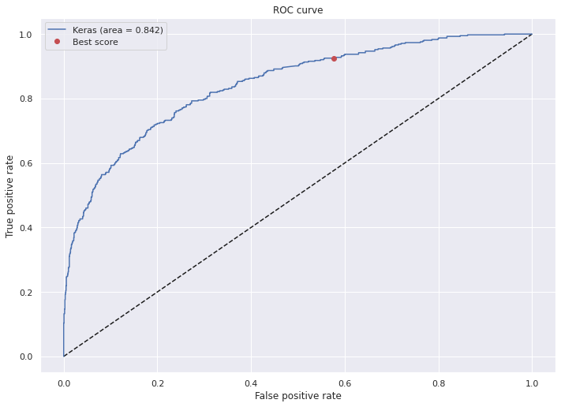

```python
plot_roc_auc(model, X_test_np, y_test_np, new_th)
```

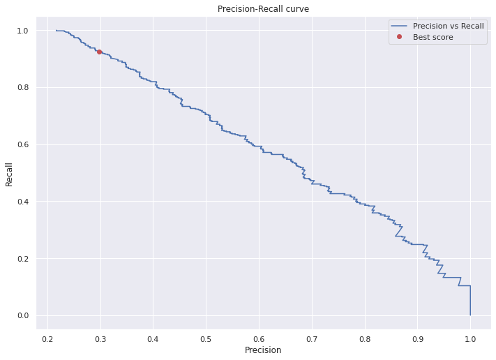

```python
plot_precision_recall(model, X_test_np, y_test_np, new_th)
```

```python
print('Test set')
print ('Metrics for default threshold:')
dummy = get_model_metrics(model, X_test_np, y_test_np, 0.5, 1)
print ('Metrics for new threshold ({0:.02}):'.format(new_th))
r, p, f1, cm, custom = get_model_metrics(model, X_test_np, y_test_np, new_th, 1)
```

```
Test set
Metrics for default threshold:
Recall: 0.79, Precision: 0.43, f1:0.56, custom metric:0.77:
Metrics for new threshold (0.077):
Recall: 0.93, Precision: 0.3, f1:0.45, custom metric:0.76:
```

```python
result = {'name': 'Early stop with modified threshold', 'recall' : r, 'precision': p, 'f1_score': f1, 'custom_metric': custom}
model_results.append(result)
```

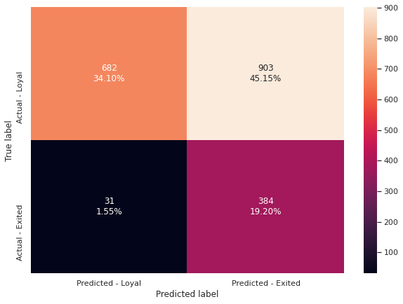

```python
make_confusion_matrix(cm)
```

## Learning rate adjustment

As mentioned earlier, loss function demonstrates oscilations which is a sign of leaning rate being too high. We can try to start reducing learning rate after certain epoch to supress oscilations

```python
from tensorflow.math import  exp

def lr_scheduler(epoch, lr):
  if epoch < 10:
    return lr
  elif epoch == 10:
    return lr * 0.5
  else:
    return lr * exp(-0.05)
```

```python
lr_cb = ks.callbacks.LearningRateScheduler(lr_scheduler)
callbacks = [lr_cb]
```

```python
model,history = buildNeuralNetwork(n_layers, n_nodes, activation, loss_f, optimizer, mult, batch,
                   epochs, X_train_np, y_train_np,
                   n_inputs, do_rate, callbacks, verbose)
```

```
Change LR from 0.0010000000474974513 to <tf.Variable 'learning_rate:0' shape=() dtype=float32, numpy=0.001>
```

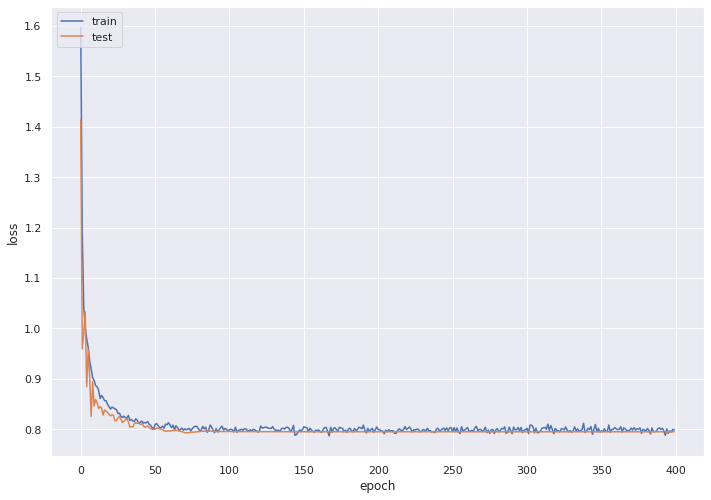

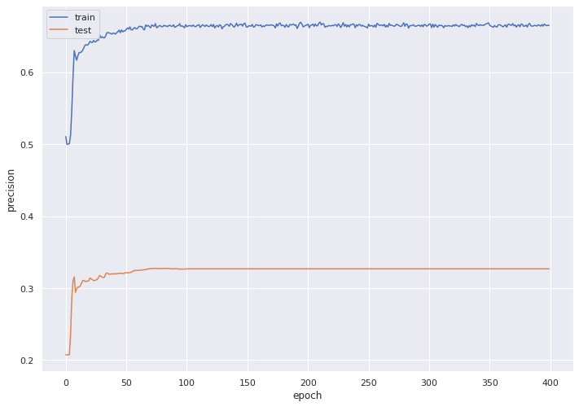

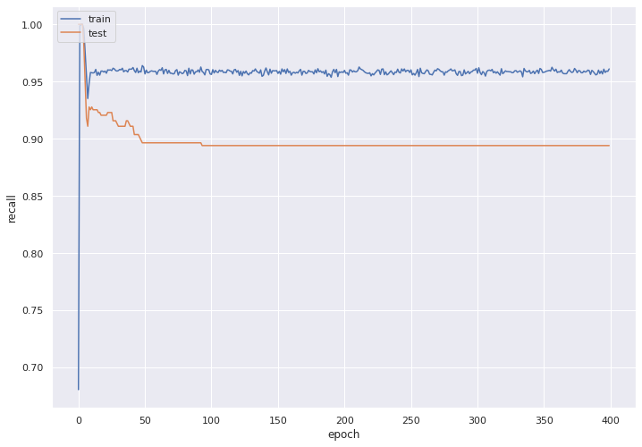

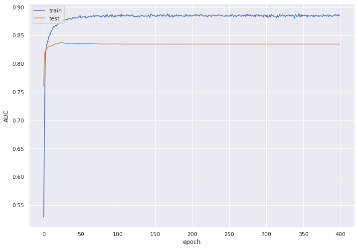

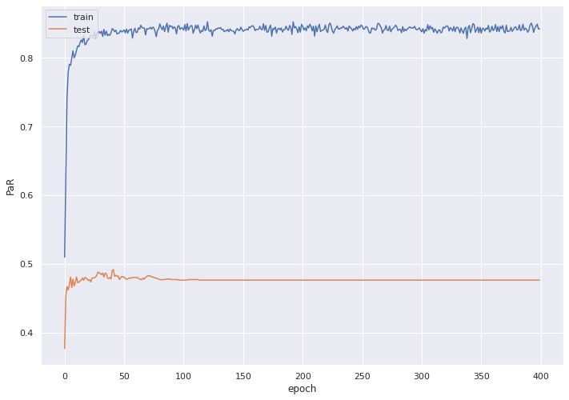

```python
plot_history(history, ['loss', 'precision', 'recall', 'AUC', 'PaR'])
```

Oscilation magnitude became significantly smaller. We can tell that the model obtained that way is more robust

```python
r, p, f1, cm, custom = get_model_metrics(model, X_train_np, y_train_np, 0.5, 1)
```

```
Recall: 0.97, Precision: 0.68, f1:0.8, custom metric:0.83:
```

```python
r, p, f1, cm, custom = get_model_metrics(model, X_test_np, y_test_np, 0.5, 1)
```

```
Recall: 0.89, Precision: 0.33, f1:0.48, custom metric:0.77:
```

```python
result = {'name': 'LR adjustment', 'recall' : r, 'precision': p, 'f1_score': f1, 'custom_metric': custom}
model_results.append(result)
```

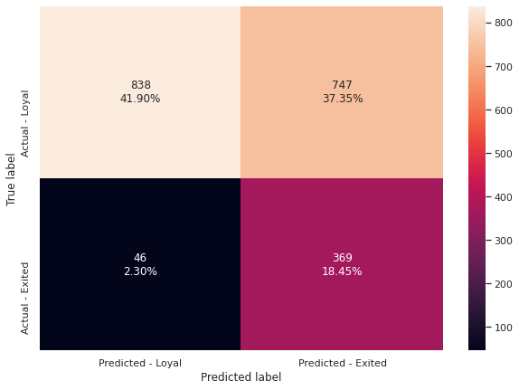

```python
make_confusion_matrix(cm)
```

Target metric didn't change, but more Exiting customers have been detected compared to initiala NN. Let's try to find optimal threshold

```python
y_pred=model.predict(X_val_np)[:,0]
pr, rc, thresholds_keras = skmetrics.precision_recall_curve(y_val_np, y_pred)

#f1 = 2 * (pr * rc) / (pr + rc)
#idx = find_nearest(f1, f1.max())

new_th = find_best_threshold(y_val_np, y_pred)
idx = find_nearest(thresholds_keras, new_th)

print ("{} Precision={}, Recall={}, Threshold={}".format(idx, pr[idx], \
                  rc[idx], thresholds_keras[idx]))
```

```
1105 Precision=0.39057239057239057, Recall=0.8385542168674699, Threshold=0.6710978746414185
```

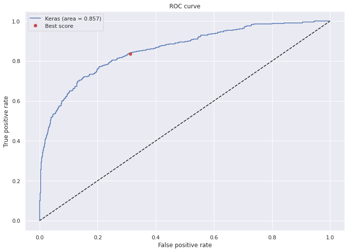

```python
plot_roc_auc(model, X_test_np, y_test_np, new_th)
```

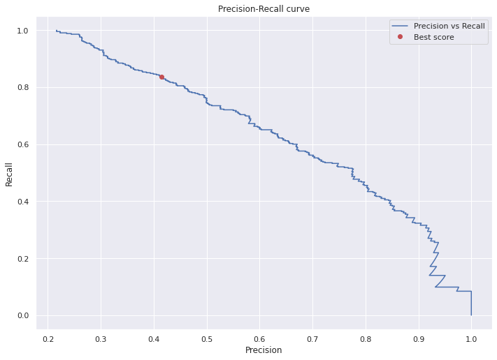

```python
plot_precision_recall(model, X_test_np, y_test_np, new_th)
```

```python
print('Test set')
print ('Metrics for default threshold:')
dummy = get_model_metrics(model, X_test_np, y_test_np, 0.5, 1)
print ('Metrics for new threshold ({0:.02}):'.format(new_th))
r, p, f1, cm, custom = get_model_metrics(model, X_test_np, y_test_np, new_th, 1)
```

```
Test set
Metrics for default threshold:
Recall: 0.89, Precision: 0.33, f1:0.48, custom metric:0.77:
Metrics for new threshold (0.67):
Recall: 0.84, Precision: 0.41, f1:0.55, custom metric:0.79:
```

```python
result = {'name': 'LR adjustment with modified threshold', 'recall' : r, 'precision': p, 'f1_score': f1, 'custom_metric': custom}
model_results.append(result)
```

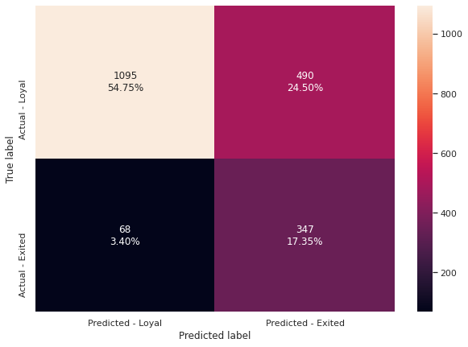

```python
make_confusion_matrix(cm)
```

## Early stop with Learning rate adjustment

Both early stop and learning rate adjustment improve model performance. Let's try them together

```python
lr_cb = ks.callbacks.LearningRateScheduler(lr_scheduler)
callbacks = [lr_cb, early_stop_cb]
```

```python
model,history = buildNeuralNetwork(n_layers, n_nodes, activation, loss_f, optimizer, mult, batch,
                   epochs, X_train_np, y_train_np,
                   n_inputs, do_rate, callbacks, verbose)
```

```
Change LR from 0.0010000000474974513 to <tf.Variable 'learning_rate:0' shape=() dtype=float32, numpy=0.001>
```

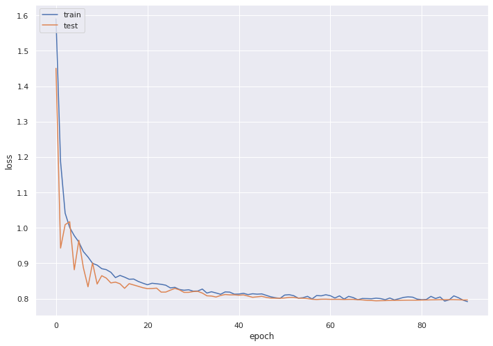

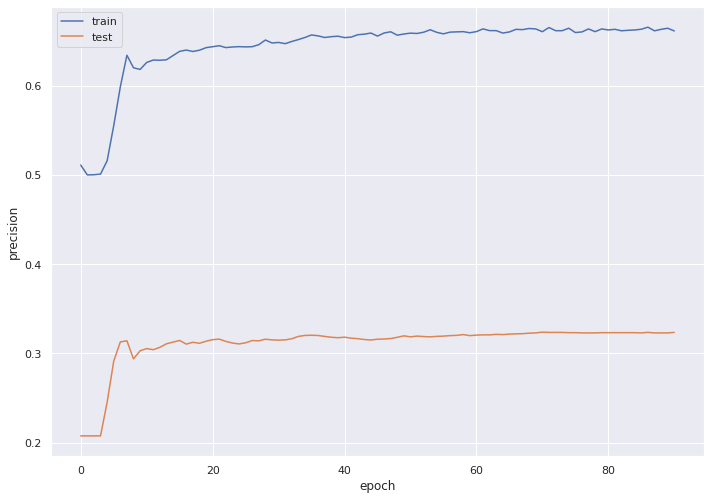

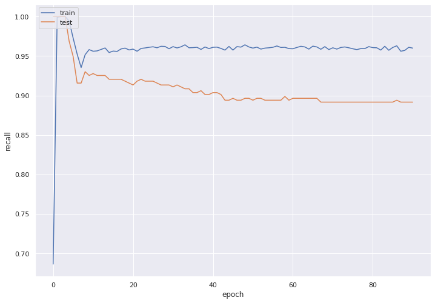

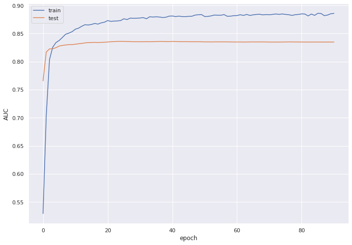

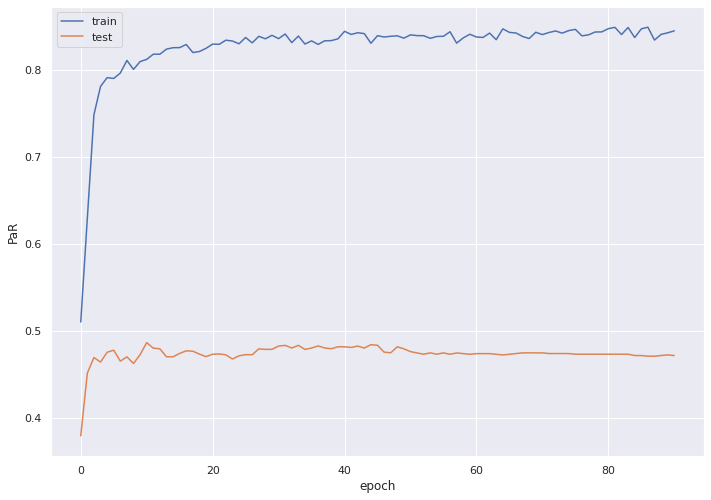

```python
plot_history(history, ['loss', 'precision', 'recall', 'AUC', 'PaR'])
```

```python
r, p, f1, cm, custom = get_model_metrics(model, X_train_np, y_train_np, 0.5, 1)
```

```
Recall: 0.97, Precision: 0.68, f1:0.8, custom metric:0.83:
```

```python
r, p, f1, cm, custom = get_model_metrics(model, X_test_np, y_test_np, 0.5, 1)
```

```
Recall: 0.89, Precision: 0.33, f1:0.48, custom metric:0.77:
```

```python
result = {'name': 'LR adjustment+Early stop', 'recall' : r, 'precision': p, 'f1_score': f1, 'custom_metric': custom}
model_results.append(result)
```

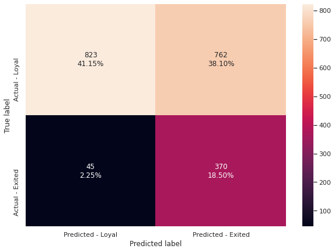

```python
make_confusion_matrix(cm)
```

Recall value is good and precision is OK compared to other models. Let's try to optimize threshold

```python
y_pred=model.predict(X_val_np)[:,0]
pr, rc, thresholds_keras = skmetrics.precision_recall_curve(y_val_np, y_pred)

#f1 = 2 * (pr * rc) / (pr + rc)
#idx = find_nearest(f1, f1.max())

new_th = find_best_threshold(y_val_np, y_pred)
idx = find_nearest(thresholds_keras, new_th)

print ("{} Precision={}, Recall={}, Threshold={}".format(idx, pr[idx], \
                  rc[idx], thresholds_keras[idx]))
```

```
947 Precision=0.34823977164605135, Recall=0.8819277108433735, Threshold=0.5650516748428345
```

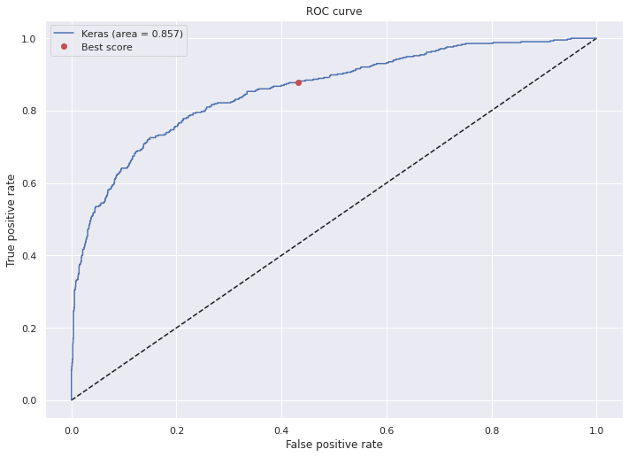

```python
plot_roc_auc(model, X_test_np, y_test_np, new_th)
```

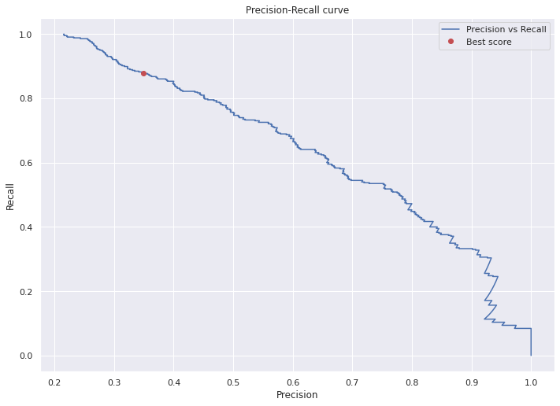

```python
plot_precision_recall(model, X_test_np, y_test_np, new_th)
```

```python
print('Test set')
print ('Metrics for default threshold:')
dummy = get_model_metrics(model, X_test_np, y_test_np, 0.5, 1)
print ('Metrics for new threshold ({0:.02}):'.format(new_th))
r, p, f1, cm, custom = get_model_metrics(model, X_test_np, y_test_np, new_th, 1)
```

```
Test set
Metrics for default threshold:
Recall: 0.89, Precision: 0.33, f1:0.48, custom metric:0.77:
Metrics for new threshold (0.57):
Recall: 0.88, Precision: 0.35, f1:0.5, custom metric:0.78:
```

```python
result = {'name': 'LR adjustment + Early stop with modified threshold', 'recall' : r, 'precision': p, 'f1_score': f1, 'custom_metric': custom}
model_results.append(result)
```

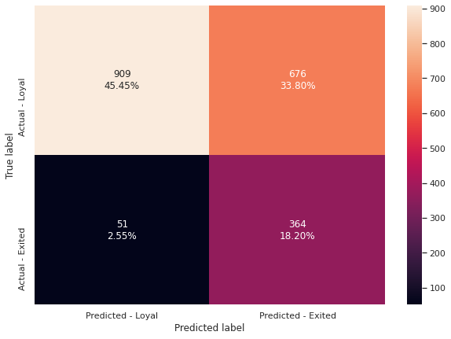

```python
make_confusion_matrix(cm)
```

Recall slightly degraded and precision slightly improved

# Model Performance Evaluation

- Evaluate the model on different performance metrics and comment on the performance and scope of improvement

```python
result_df = pd.DataFrame(data=model_results)
```

```python
result_df
```

|  | name | recall | precision | f1_score | custom_metric |
| --- | --- | --- | --- | --- | --- |
| 0 | First try | 0.708434 | 0.494118 | 0.582178 | 0.742321 |
| 1 | First try with modified threshold | 0.862651 | 0.363452 | 0.511429 | 0.776573 |
| 2 | Early stop | 0.787952 | 0.430263 | 0.556596 | 0.767572 |
| 3 | Early stop with modified threshold | 0.925301 | 0.298368 | 0.451234 | 0.760295 |
| 4 | LR adjustment | 0.889157 | 0.330645 | 0.482038 | 0.769007 |
| 5 | LR adjustment with modified threshold | 0.836145 | 0.414576 | 0.554313 | 0.787714 |
| 6 | LR adjustment+Early stop | 0.891566 | 0.326855 | 0.478345 | 0.767458 |
| 7 | LR adjustment + Early stop with modified thres... | 0.877108 | 0.350000 | 0.500344 | 0.775906 |

- Threshold optimizatios doesn't add much value to our custom metric. It just rundomly increse recall and decrese precision or the othe way around. Since the behaviour of this technique is unpredictable for this type of problem, we won't consider models with modified threshold
- Neural network with learning rate adjustment and early stop has a high recall. It also stops at the minimum of the loss function for validation set and has a very small loss function oscilation magnitude at the end of the curve, which is a sign of good fit. We would recommend this model

Further improvement model can include:

- Hyperparameter tuning for loss functions, number of nodes/layers, activation functios, dropout ratio
- Different weight initialization techniques
- Seeding random number generators with different values to find better a local minimum
- Adopt global otimization technique like Similated annealing to find a global minimum

# Conclusion and key takeaways

- NN performance is sensetive to different parametrs like number of layers and nodes, activation and loss functios
- Divergence of training and validataion loss functions can be fixed by adding layers and nodes. For fine tuning add nodes, for coarse tuning add layers
- NN training results are sensetive to initial weigh, which means it's a global optimization problem
- Callbacks like **Learning rate scheduling** and **early stop** help to improve NN training proces

# End of the project. Thank you